# Introduction to Statistics with R

MILS 2026

Ludovic De Cuypere

Ludovic.DeCuypere@ugent.be

UGent & VUB

## Overview

- Understanding data
- Two variables
- The normal distribution
- The sampling distribution of the mean
- Significance testing:
  - PART 1 (the practical part)
  - PART 2 (the theoretical part)

# Understanding data

## Data

| Participant | Group | L1 | Score |
| --- | --- | --- | --- |
| 1 | A | monolingual | 14 |
| 2 | A | monolingual | 15 |
| 3 | A | bilingual | 13 |
| … | … | … |  |
| 28 | B | bilingual | 15 |
| 29 | B | multilingual | 18 |
| 30 | B | monolingual | 9 |

## Two types of variables

1. Categorical variable (also called “qualitative”)
   - limited number of values
   - countable
2. Continuous variable (also called “quantitative”)
   - measurable

## Your turn

What type of variable is:

```
-   Sentence length (in number of words)
-   Age (in years)
-   Rating on a Likert scale
```

## Understanding the data

- what are the possible values?
- what is a “typical” value (“central tendency”)?
- what is an “unlikely”, “possible”, or “likely” observation?
- how likely is each possible value?

**Important**

Describing a variable means to visualize and to provide key numbers of the distribution of a variable.

## Univariate summary

A univariate summary describes some key numbers of the distribution of a variable.

- Categorical variable
  - frequency + proportion
- Continuous variable
  - measures of central tendency
  - measures of dispersion

## Continuous variable

- Measures of central tendency
  - Mean
  - Median
  - Mode
- Measures of dispersion
  - Minimum
  - Maximum
  - Quartiles (Deciles and Percentiles)
  - Variance & Standard deviation
  - MAD (Median Absolute Deviation)

## Sample mean

We consider a dataset with the heights of $N=20$ basketball players.

```r
height <- c(184, 217, 191, 196, 205, 177, 209, 185, 200, 189,
            221, 221, 194, 173, 196, 201, 188, 182, 189, 196)
height
```

```
 [1] 184 217 191 196 205 177 209 185 200 189 221 221 194 173 196 201 188 182 189
[20] 196
```

## Boxplot

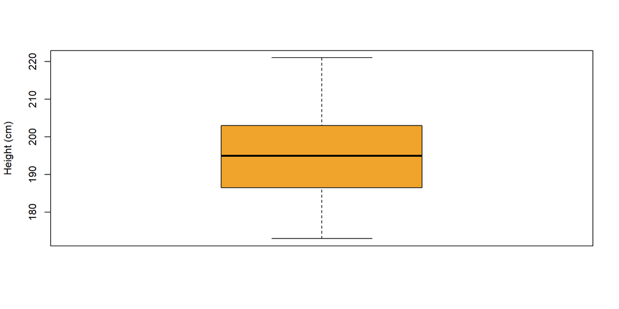

```r
boxplot(height,
        col = "#F1A42B",
        Las = 1,
        ylab = "Height (cm)")
```

## Your turn

Same data:

```r
height <- c(184, 217, 191, 196, 205, 177, 209, 185, 200, 189,
            221, 221, 194, 173, 196, 201, 188, 182, 189, 196)
```

Create a boxplot in green.

## Histogram

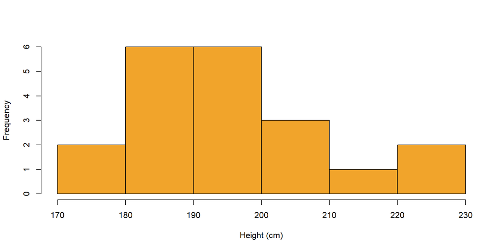

```r
hist(height,
     col = "#F1A42B",
     xlab = "Height (cm)",
     main = "")
```

## Histogram: 6 breaks

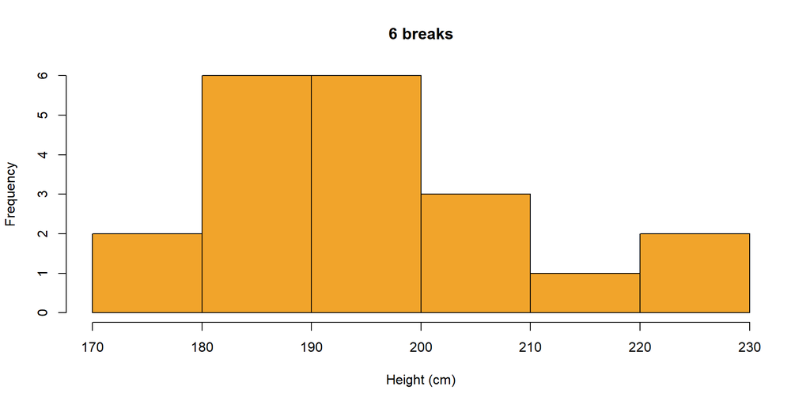

```r
hist(height,
     col = "#F1A42B",
     breaks = 6,
     main = "6 breaks",
     xlab = "Height (cm)")
```

## Histogram: 40 breaks

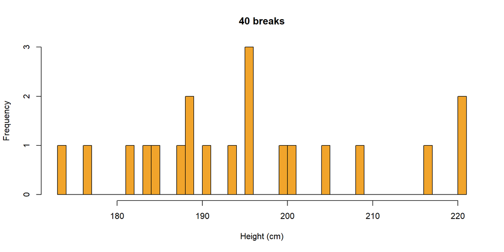

```r
hist(height,
     col = "#F1A42B",
     breaks = 40,
     main = "40 breaks",
     xlab = "Height (cm)")
```

## A skewed distribution

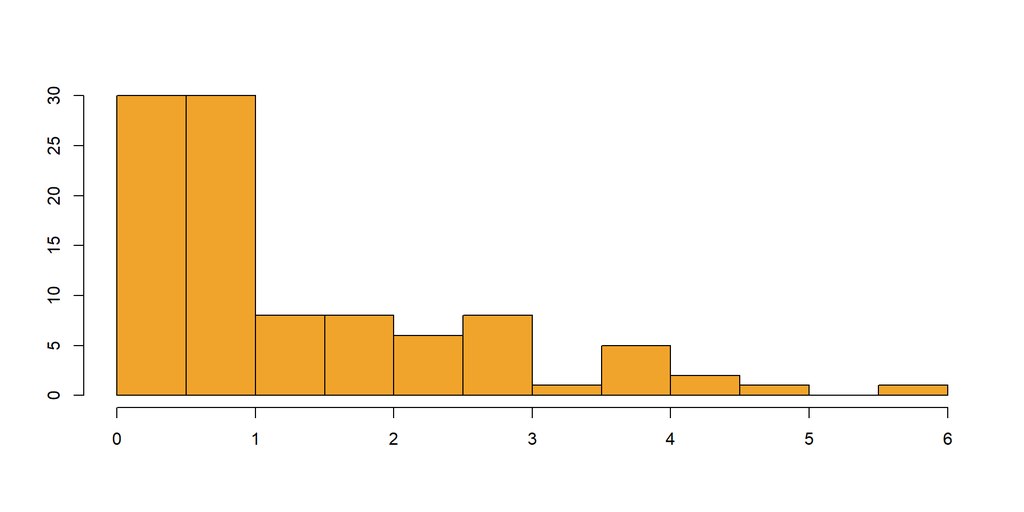

```r
hist(exp(rnorm(100)),
     main="",
     xlab = "",
     ylab = "",
     col = "#F1A42B")
```

## A bimodal distribution

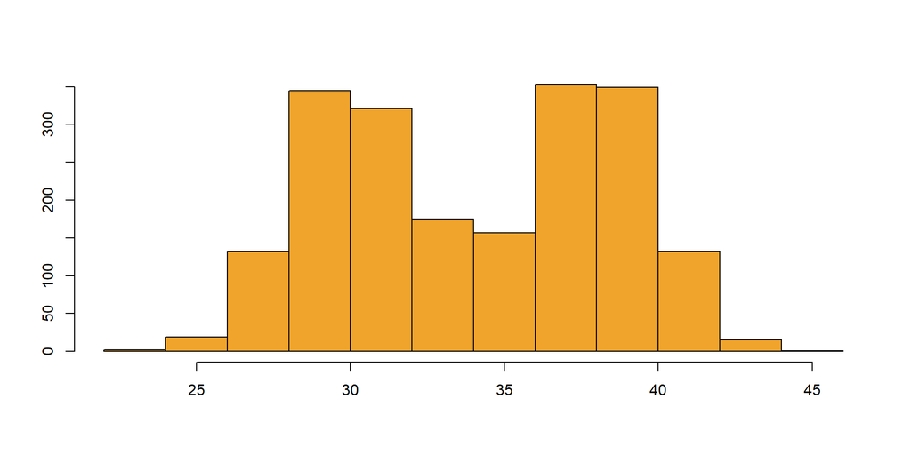

```r
hist(c(rnorm(1000, mean = 30, sd = 2),
       rnorm(1000, mean = 38, sd = 2)),
     main="",
     xlab = "",
     ylab = "",
     col = "#F1A42B")
```

## Density curve

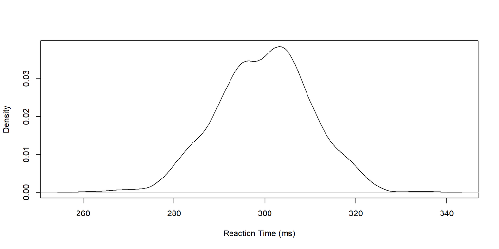

```r
ReactionTime <- rnorm(n = 1000, mean = 300, sd = 10)
densRT <- density(ReactionTime)
plot(densRT,
     main = "",
     ylab = "Density",
     xlab = "Reaction Time (ms)")
```

## Stripchart

```r
sampleRT <- sample(x = ReactionTime, size = 8)
stripchart(sampleRT,
           xlab = "Reaction time (ms)",
           pch = 1)
```

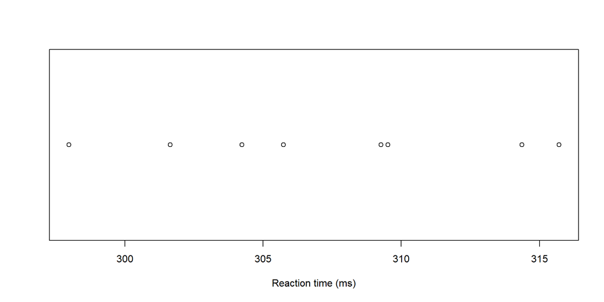

## Mean

$$\bar{X} =\frac{1}{n}\sum_{i=1}^{n}x_i$$

$$\begin{split}
\bar{X} & =\frac{x_1+x_2+...+x_n}{n} \\
& =\frac{1}{n}(x_1+x_2+...+x_n) \\
& =\frac{1}{n}
\sum_{i=1}^{n}x_i
\end{split}$$

## R

```r
sum(height)/length(height)
```

```
[1] 195.7
```

via `mean()`:

```r
mean(height, na.rm = TRUE) # use na.rm when there are missing values
```

```
[1] 195.7
```

## Median

The median is a location value. A location value is defined as follows for a sample $X_{(1)},...,X_{(n)}$:

$$\begin{split}
X_{(1)}&=\min_{1 \le i\le n} X_i, \\
X_{(2)}&=\text{second smallest value} X_i, \\
\vdots \\
X_{(n)}&=\max_{1 \le i \le n} X_i.\\
\end{split}$$

## R

```r
sort(height, decreasing = FALSE)
```

```
 [1] 173 177 182 184 185 188 189 189 191 194 196 196 196 200 201 205 209 217 221
[20] 221
```

The median is defined as in Equation 1:

$$M=
\begin{cases}
X_{((n+1)/2)} &\text{if}~n~\text{uneven} \\
(X_{(n/2)}+X_{(n/2+1)})/2 &\text{if}~n~\text{even}
\end{cases}
\tag{1}$$

- `height` includes $n=20$ observations.
- The median is de average of the two middle values: $X_{(10)}=194$ en $X_{(11)}=196$. Hence: $(194+196)/2=195$.

```r
median(height)
```

```
[1] 195
```

## Mode

The mode is the value that occurs most frequently. It is useful for categorical variables or when the continuous variable contains rounded values (so that we have multiple observations of the same value). You can find the mode using `table()` to identify the value with the highest frequency.

## Measures of Dispersion

Look at the `height` data:

```r
stripchart(height, xlab = "height (cm)", xlim = c(160, 230))
points(x = mean(height), y = 1, col = "red", pch = 18, cex = 2)
```

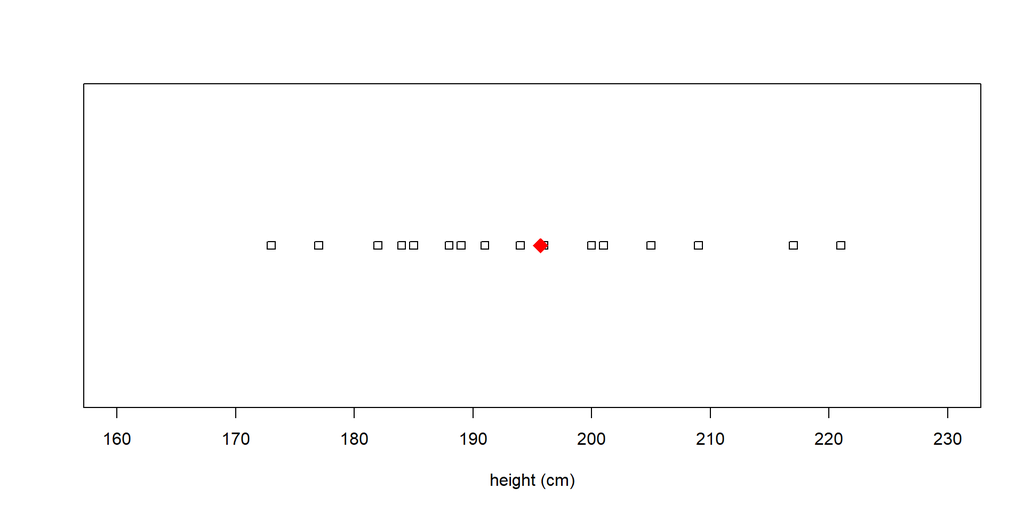

## Location measurements

```r
min(height)
```

```
[1] 173
```

```r
median(height)
```

```
[1] 195
```

```r
max(height)
```

```
[1] 221
```

```r
range(height)
```

```
[1] 173 221
```

## Location measurements

```r
quantile(x = height, probs = c(0.25))
```

```
   25%
187.25
```

```r
quantile(x = height, probs = c(0.25, 0.75))
```

```
   25%    75%
187.25 202.00
```

```r
quantile(x = height, probs = c(0.10, 0.90))
```

```
  10%   90%
181.5 217.4
```

## Sample variance

$$s^2=\frac{1}{n-1}\sum_{i=1}^{n}(x_i-\bar{X})^2$$

“The average distance between the sample observations and the sample average”

## Standard deviation

$$s=\sqrt{s^2}=\sqrt{\frac{1}{n-1}\sum_{i=1}^{n}(x_i-\bar{X})^2}$$

## Example

```r
var(height)
```

```
[1] 185.3789
```

```r
sd(height)
```

```
[1] 13.61539
```

## Mean Absolute Deviation

$$\text{MAD}=\frac{1}{n-1}\sum_{i=1}^{n}|x_i-\bar{X}|$$

## Exercise 1

We measured the average reaction time (in ms) of 20 Participants:

| 347 | 338 | 342 | 334 |
| --- | --- | --- | --- |
| 351 | 348 | 322 | 455 |
| 329 | 348 | 390 | 355 |
| 359 | 360 | 350 | 362 |
| 329 | 327 | 334 | 333 |

1. Create a vector in R called `RT` and assign the measurements to this object.
2. How many observations are there? (use a function, don’t count)
3. What is the average Reaction Time?
4. Use R to calculate:
   - maximum
   - minimum
   - median
   - standard deviation
5. Visualise the distribution by means of:
   - a boxplot
   - a histogram

## Categorical data

We asked 10 participants about their educational level, operationalized as a three level categorical variable:

- “high”: highschool level
- “ba”: bachelor level
- “ma”: Master level

## Your turn

Create a vector called `Edulevel`

```r
EduLevel <-c("high", "high", "ba", "high", "ba",
             "ma", "ma", "ma", "high", "ma")
```

## Your turn

Use a `str()` to find out what kind of variable `EduLevel` is.

```r
str(EduLevel)
```

```
 chr [1:10] "high" "high" "ba" "high" "ba" "ma" "ma" "ma" "high" "ma"
```

## From character to factor

Transform the character variable to a factor:

```r
EduLevel <- as.factor(EduLevel)
str(EduLevel)
```

```
 Factor w/ 3 levels "ba","high","ma": 2 2 1 2 1 3 3 3 2 3
```

`EduLevel` is now a factor variable with three categories or levels. R assigns a number to every category. Levels are assigned alphabetically. This can be overruled and the levels can be binned with the `levels()` function.

## Contingency table

We summarize the factor variables by means of the `table()` function.

```r
table(EduLevel)
```

```
EduLevel
  ba high   ma
   2    4    4
```

## Proportions

Proportions or fractions are calculated with `prop.table()`, applied to the object of `table()`

```r
prop.table(table(EduLevel))
```

```
EduLevel
  ba high   ma
 0.2  0.4  0.4
```

## Barplot

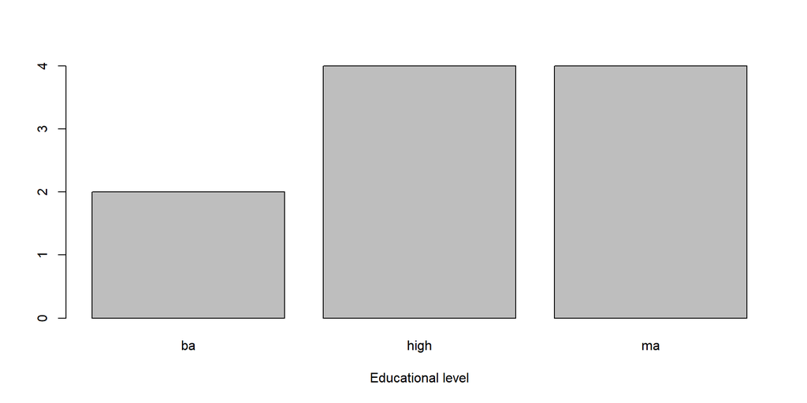

```r
barplot((table(EduLevel)), xlab = "Educational level")
```

# Two variables

## Scatterplot

- Here is a mock dataset for ten participants who performed a pre- and posttest.

| ID | Pretest | Posttest |
| --- | --- | --- |
| 1 | 13 | 15 |
| 2 | 8 | 9 |
| 3 | 11 | 16 |
| 4 | 12 | 13 |
| 5 | 16 | 17 |
| 6 | 15 | 17 |
| 7 | 11 | 12 |
| 8 | 6 | 10 |
| 9 | 10 | 13 |
| 10 | 14 | 15 |

## Data

```r
Pretest <- c(13, 8, 11, 12, 16, 15,
             11, 6, 10, 14)
Posttest <- c(15, 9, 16, 13, 17, 17,
              12, 10, 13, 15)
```

## Clustered boxplots

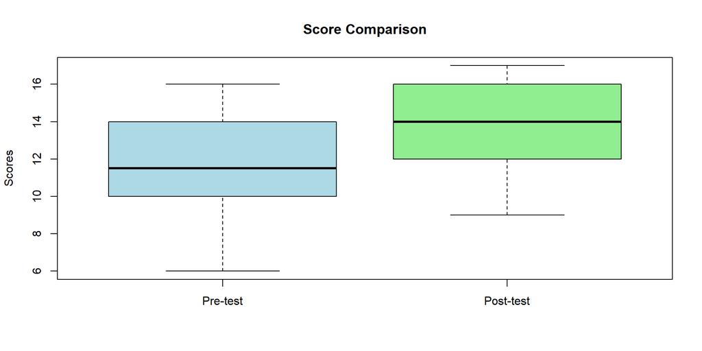

```r
boxplot(Pretest, Posttest,
        names = c("Pre-test", "Post-test"),
        col = c("lightblue", "lightgreen"),
        main = "Score Comparison",
        ylab = "Scores")
```

- QUESTION: What information is missing from this visualisation?

## Scatterplot with a linear regression line

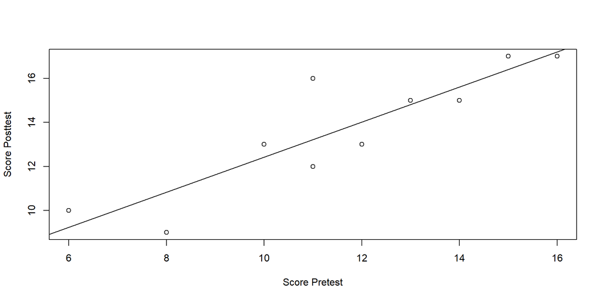

```r
plot(x = Pretest, y = Posttest,  # x-axis and then y-axis!
      xlab = "Score Pretest",
      ylab = "Score Posttest")
abline(lm(Posttest ~ Pretest)) # note the reversal of variables!
```

- QUESTION: What information is missing from this visualisation?

## Exercise 2

Ask Gemini to visualise the pre-posttestdata by means of a spaghettiplot. Advise it to use tidyverse and ggplot2. You want to understand every line of code, so you also ask it to document every line of code.

- QUESTION: What information is missing from this visualisation?

**Note**

1. There is never one single correct visualisation of a dataset.
2. Every visualisation is a comparison.
3. What is the key message that you want to communicate?

## Categorical data

- Here is a mock dataset for ten speakers of English (native and non-native speakers) and whether they used a monophthong for the PRICE /aɪ/vowel.

[output not shown]

## Bivariate table

```r
Native <- c("no", "no", "no", "yes", "yes", "no", "no", "no", "yes", "no")
Mono <- c("yes", "yes", "yes", "yes", "no", "yes","no", "no", "no", "yes")
cat <- data.frame(Native, Mono)
head(cat)
```

```
  Native Mono
1     no  yes
2     no  yes
3     no  yes
4    yes  yes
5    yes   no
6     no  yes
```

## Bivariate table (1)

```r
table("Native English" = cat$Native, # adding the variable gives a nicer table
      "Monophthong" = cat$Mono)
```

```
              Monophthong
Native English no yes
           no   2   5
           yes  2   1
```

## Bivariate table (2)

```r
xtabs(~ Native + Mono, data = cat)
```

```
      Mono
Native no yes
   no   2   5
   yes  2   1
```

## Bivariate summary (3)

```r
library(tidyverse)
cat |> count(Native, Mono)
```

```
  Native Mono n
1     no   no 2
2     no  yes 5
3    yes   no 2
4    yes  yes 1
```

## Bivariate summary (4)

```r
as.data.frame(table("Native English" = cat$Native,
                    "Monophthong" = cat$Mono))
```

```
  Native.English Monophthong Freq
1             no          no    2
2            yes          no    2
3             no         yes    5
4            yes         yes    1
```

## Bivariate barplot

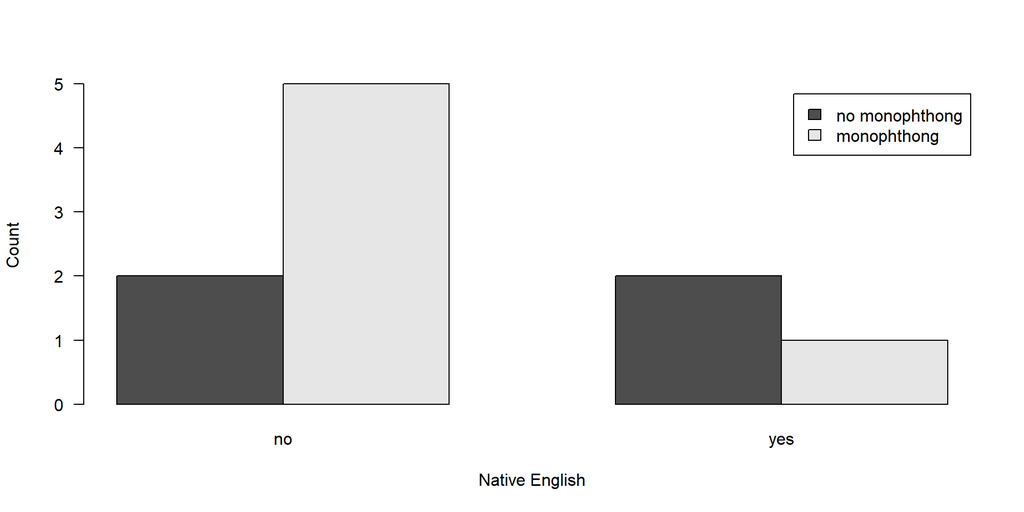

```r
barplot(table(cat$Mono, cat$Native),
        xlab = "Native English",
        ylab = "Count",
        legend.text = c("no monophthong", "monophthong"),
        beside = TRUE,
        las = 1)
```

## Exercise 3: dataset

For this exercise we use the phonetic data by Verbeke & Van Praet (2025)

> ABSTRACT: This dataset contains the measurements of 210 checked steady-state vowels. Previous studies have shown that suprasegmental factors have an impact on the duration of vowels, such as prosodic boundary strength and the proximity to the end of an intonation unit boundary. To the previous findings, this study adds another potential factor, namely the difference between primary accented, secondary accented, and non-accented syllables. By diversifying between these factors, we seek to establish the actual influence that each factor might have on the duration steady-state vowels, which will be assessed using multiple linear mixed-effects regression models. R code for the data analysis is provided.

## Exercise 3 (Part 1)

1. Import the dataset `Accentuation_Dataset.csv` in R.
2. Give a general summary of all the variables with the `summary()` function.
3. Summarize the variable `Duration_ms`:
   - mean
   - median
   - min
   - max
   - standard deviation

## Exercise 3 (Part 2)

4. Visualise the variable `Duration_ms` by means of:
   - a histogram
   - a boxplot
5. Centering the data means to create a new variable by taking the difference between each observation and the mean of the variable. Center the data and create a histogram of this centered variable. Is the shape of the histogram different than the histogram of the uncentered data?
6. Summarize the variable `ACC` (Accentuation status). Give the frequencies and proportions of the levels.

## Exercise 3 (Part 3)

7. Create a scatterplot to compare the measurements by the two annotators. Use `abline()` to add a regression line to visualize any linear trend.
8. Create clustered boxplots to compare `Duration_ms` by Accentuation status`.
9. Use the function `xtabs()` to recreate table 1 from the README document shared in the dataset

# The Normal distribution

## The normal distibution

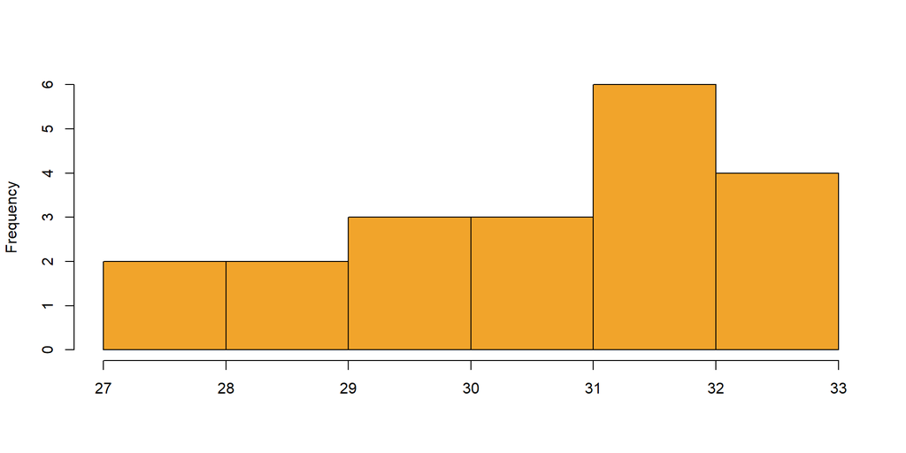

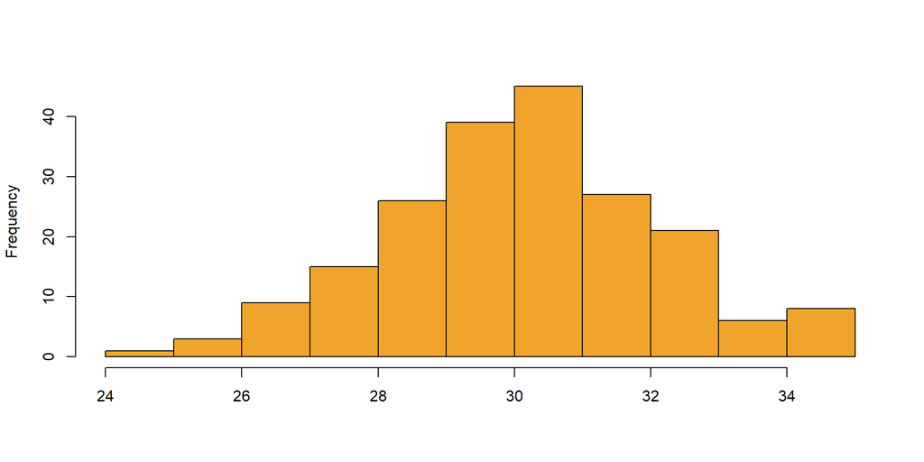

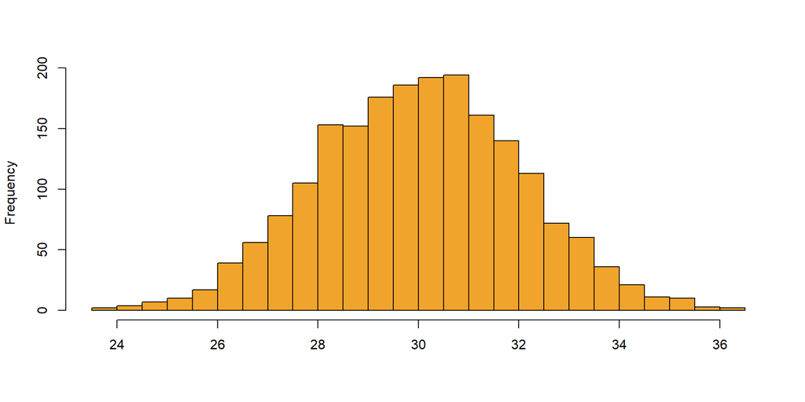

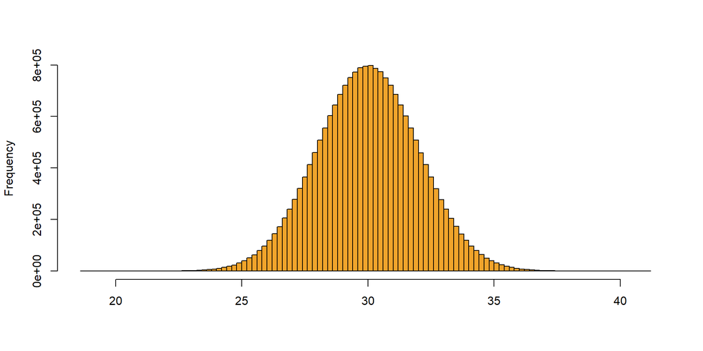

## The normal distribution

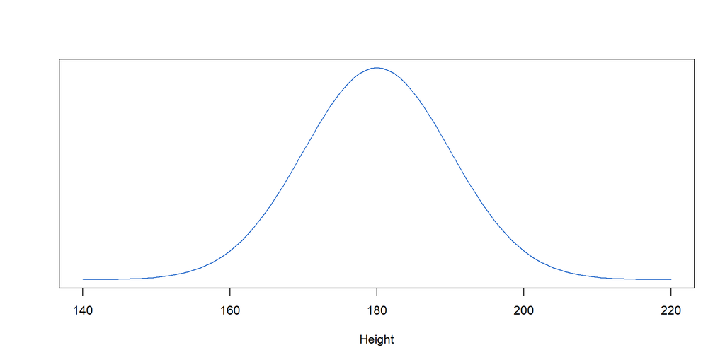

```r
plot(function(x)dnorm(x, mean = 180, sd = 10),
     from = 140,to = 220,
     col="#1E64C8", ylab = "", yaxt="n", xlab = "Height")
```

## The normal distribution

$$X \sim N(\mu,\sigma^2)$$

- read: “$X$ is a normally distributed variable with mean $\mu$ and variance $\sigma^2$”.
- density function:

$$f(x)=\frac{1}{\sigma \sqrt{2\pi}}e^{-\frac{1}{2}\left(\frac{x-\mu}{\sigma}\right)^2}$$

## The normal distribution

With $\mu = 180$ and $\sigma = 10$, and input values $X_i$ between $140$ and $220$.

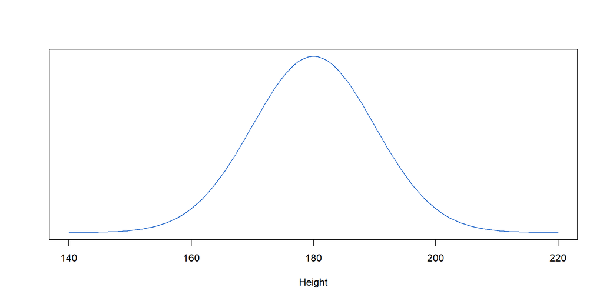

```r
plot(function(x)dnorm(x, mean = 180, sd = 10),
     from = 140,to = 220,
     col="#1E64C8", ylab = "", yaxt="n", xlab = "Height")
```

## Different mean

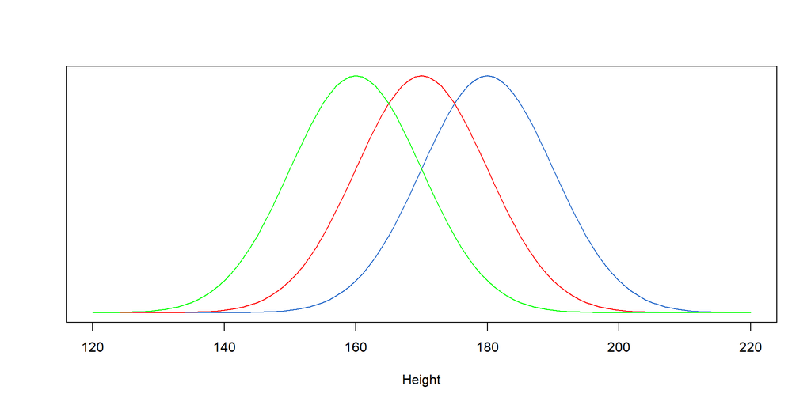

## Different variance

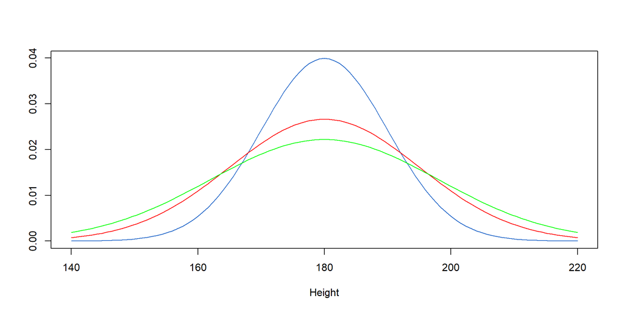

## Z-score

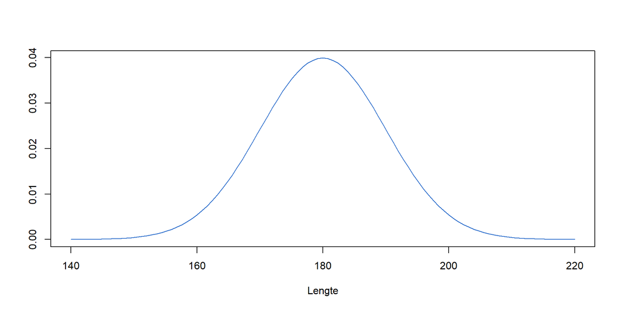

- The total surface below the curve is equal to $100\%$ or $1$.
- The probability of finding an observation greater than 200 but less than 210 is the area under the curve from $200$ to $210$.

## Standardising

Population

$$Z=\frac{X_i-\mu}{\sigma}$$

Sample

$$Z=\frac{X_i-\bar{X}}{s}$$

## Example

- We calculate the z-score for a person with a height of 221 cm in a normal distribution with a mean ($\mu = 180$) and standard deviation ($\sigma = 10$):

```r
z <- (221-180)/10
z
```

```
[1] 4.1
```

Z-score = the number of standard deviations above the mean.

## Your turn

For a normal distribution with $\mu = 180$ and $\sigma = 10$, calculate the z-score of the following values

- 180
- 190
- 200
- 223
- 258

## Solution

```r
values <- c(180, 190, 200, 223, 258)
z <- (values-180)/10
z
```

```
[1] 0.0 1.0 2.0 4.3 7.8
```

## Exercise 4

Let’s look at the heights of the 20 basketball players again.

```r
height <- c(184, 217, 191, 196, 205, 177, 209, 185, 200, 189,
            221, 221, 194, 173, 196, 201, 188, 182, 189, 196)
```

- Standardise the Height variable. Call this new variable `Height_z`.
- Interpret the new variable.
- What is the average of `Height_z`?

# The **standard** normal distribution

## The standard normal distribution

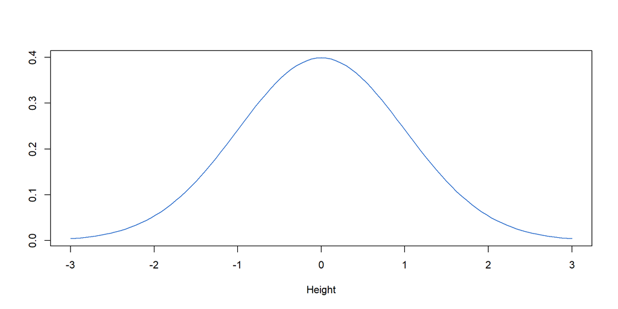

## The standard normal distribution

- Notation: $X \sim N(\mu = 0, \sigma = 1)$.
- Every normal distribution can be transformed into a standard normal one. This is called **standardising**.

## Example

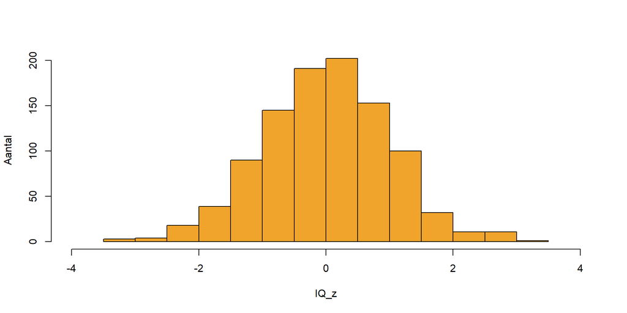

```r
s <- rnorm(n = 1000, mean = 100, sd = 13)
s_z <- scale(s, center = TRUE, scale = TRUE)
hist(s_z, col = "#F1A42B",
     main = "", ylab = "Aantal",
     xlab = "IQ_z",
     xlim=c(-4,4))
```

## 68-95-99.7 rule

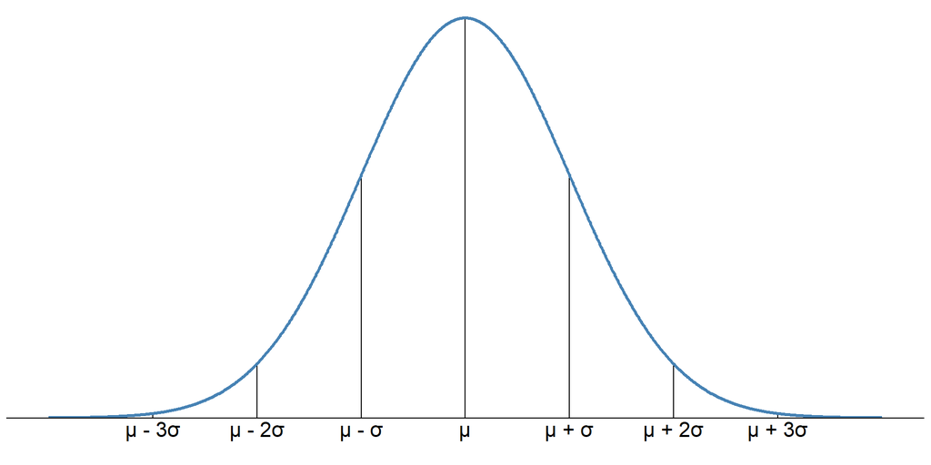

## Cumulative proportions

- Given: $Height \sim N(\mu = 180, \sigma =10)$
- What is: $P(Height>160)$?

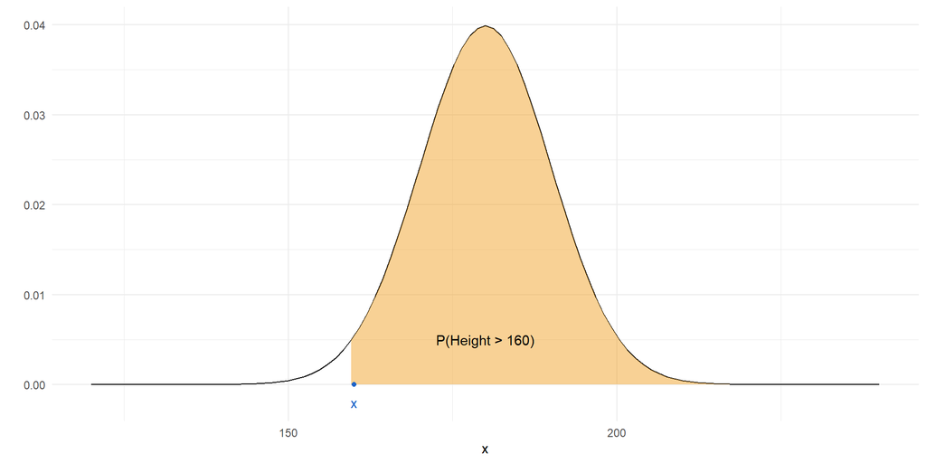

## R: `pnorm()`

```r
z <- (160-180)/10
pnorm(q = z, mean = 0, sd = 1, lower.tail = FALSE)
```

**1**

calculate z-score;

**2**

use `pnorm()` to get the proportion.

```
[1] 0.9772499
```

## Critical value

- Given: $Height \sim N(\mu = 180, \sigma =10)$
- What is $x$ for: $P(Height<x) = 5\%$?

$$\begin{split}
z & =\frac{x_i-\mu}{\sigma} \\
z*\sigma & =x_i-\mu \\
z*\sigma + \mu & = x_i
\end{split}$$

## Example

- We are looking for the value such that the proportion smaller than that value is equal to $5\%$.
- So what is that value for the standard normal distribution ($\,=z$)?
- We use `qnorm()`.

```r
qnorm(p = 0.05,
      mean = 0,
      sd = 1,
      lower.tail = TRUE)
```

```
[1] -1.644854
```

## Example

Plug everything we know into the formula $x_i=\mu+z*\sigma$

```r
180-(1.64*10)
```

```
[1] 163.6
```

$5\%$ of all values on a normal distribution with $\mu = 180$ and $\sigma=10$ is smaller than $163.6\;cm$.

## Exercise 5

IQ-measurements are normaly distributed with $\mu=100$ and $\sigma=15$. What percentage of the population has:

- $IQ<90$
- $70<IQ<130$
- $105<IQ<120$
- $P(IQ>100)?$

## Normality

We can evaluate whether a sample comes from a normally distributed variable in multiple (complementary) ways:

1. What is the data generating proces?
2. Histogram, boxplot, density curve
3. QQ-plot
4. Statistical test (e.g. Kolmogorov-Smirnov)

## Example

```r
Height<-c(184,217,191,196,205,177,209,185,200,189,
          221,221,194,173,196,201,188,182,189,196)
```

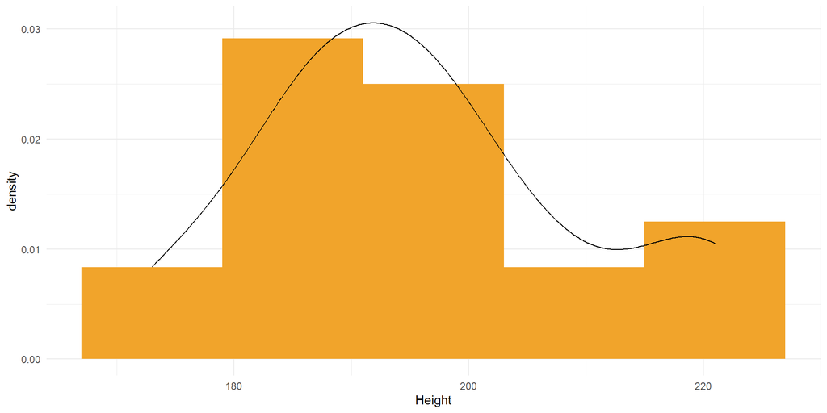

```r
library(ggplot2)
df <- data.frame(Height)
ggplot(df, aes(x = Height)) +
  geom_histogram(bins = 5,
                 fill = "#F1A42B",
                 aes(y = after_stat(density))) +
  geom_density()  +
  theme_minimal()
```

## QQ-plot

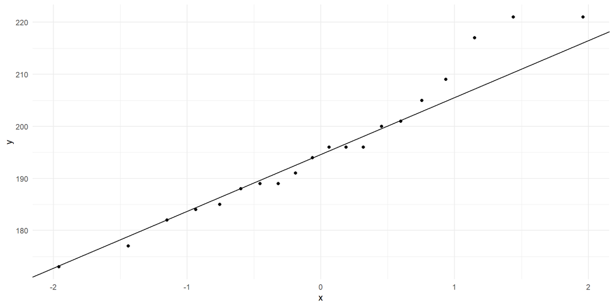

```r
ggplot(df,
       aes(sample = Height)) +
  stat_qq() +
  stat_qq_line() +
  theme_minimal()
```

## Shapiro-Wilk test

```r
shapiro.test(x = Height)
```

```
    Shapiro-Wilk normality test

data:  Height
W = 0.95503, p-value = 0.4499
```

## Exercise 6

1. Is `Duration_ms` from Verbeke & Van Praet (2025) normally distributed?

# Sampling distribution of the mean

## Driving question

> What would happen if we took multiple samples?

## Example: Height

- We take three random samples from a population Height ~ N( $\mu = 180$, $\sigma=10$).
- Calculate the sample means.

```r
S_1 <- rnorm(n = 200, mean = 180, sd = 10)
samplemean_1 <- mean(S_1)
samplemean_1
```

```
[1] 179.4693
```

```r
S_2 <- rnorm(n = 200, mean = 180, sd = 10)
samplemean_2 <- mean(S_2)
samplemean_2
```

```
[1] 179.3357
```

```r
S_3 <- rnorm(n = 200, mean = 180, sd = 10)
samplemean_3 <-mean(S_3)
samplemean_3
```

```
[1] 179.8762
```

## The sampling distribution of the mean

Let’s take $2000$ samples.

```r
S_2000 <- replicate(n = 2000,
                          expr = rnorm(n = 200,
                                       mean = 180,
                                       sd = 10))
S_2000[1:10, 1:5]
```

```
          [,1]     [,2]     [,3]     [,4]     [,5]
 [1,] 188.3009 189.5331 178.4404 152.9695 172.4676
 [2,] 185.5490 179.3141 175.8346 189.4121 196.0894
 [3,] 177.4017 184.4336 180.9894 158.6011 185.0604
 [4,] 189.7911 176.8026 178.4064 174.1023 160.4998
 [5,] 172.2125 185.1210 179.8943 198.0007 194.6143
 [6,] 165.6550 185.5340 172.9407 175.8073 191.9036
 [7,] 161.7592 159.5675 187.0214 175.1418 177.4574
 [8,] 174.4475 166.0029 163.5672 175.3426 177.1780
 [9,] 175.5580 169.9552 176.5529 164.8904 180.8788
[10,] 168.9193 175.8619 176.7955 160.8122 191.2070
```

## The sampling distribution

The average for every sample (one sample = one column)

```r
S_means <- colMeans(S_2000)
head(S_means, 20)
```

```
 [1] 179.8215 180.0267 179.0515 180.0533 179.6216 180.7973 180.0690 179.5120
 [9] 180.8477 180.2154 179.2207 180.0986 180.0834 179.0809 180.5654 179.0571
[17] 178.9910 179.6937 180.1452 180.7113
```

## The sampling distribution

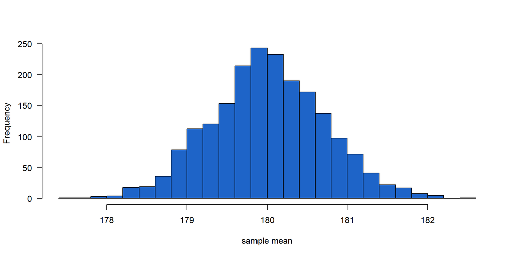

```r
hist(S_means, col = "#1E64C8",
                       main = "",
                       ylab = "Frequency",
                       xlab = "sample mean",
                       las = 1,
                       breaks = 20)
```

## The sampling distribution vs. population distribution

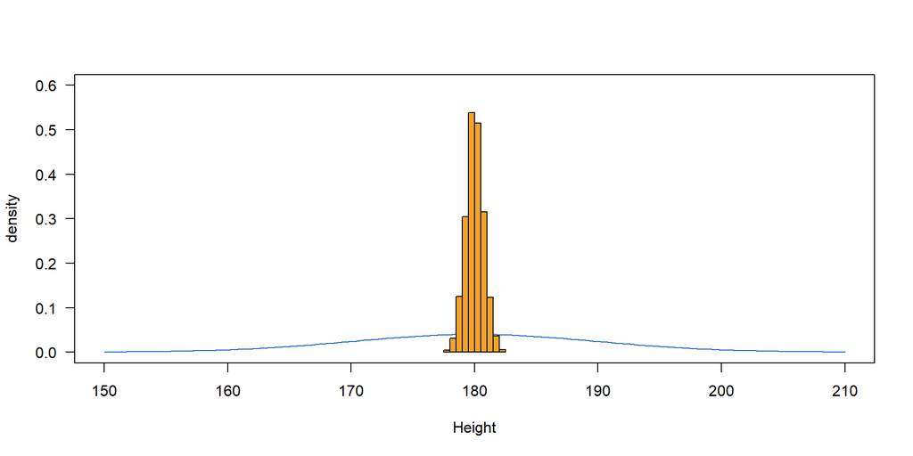

## The sampling distribution vs. population distribution

The standard deviation of the population was $\sigma=10$. What is the standard deviation of the sampling distribution?

```r
sd(S_means)
```

```
[1] 0.7117647
```

A lot smaller!

## Standard Error

$\sigma$ known

$$SE = \frac {\sigma}{\sqrt{n}}\\$$

(n = size of the sample)

$\sigma$ unknown

$$SE = \frac {s}{\sqrt{n}}\\$$

## The sampling distribution

For $\bar{X} \sim N(\mu, \sigma/\sqrt{n})$:

$$\frac{\bar{X}-\mu}{\frac{\sigma}{\sqrt{n}}}\sim N(0,1)$$

## Student-t distribution

In most cases, we will not know $\sigma$. If we estimate $\sigma$ by s (the sample standard deviation), the standardized sampling distribution of the mean no longer follows a normal distribution, but a **t-distribution** with (n-1) degrees of freedom (abbreviated as ‘df’):

$$\frac{\bar{X}-\mu}{\frac{s}{\sqrt{n}}}\sim t_{n-1}$$

## Student-t distribution

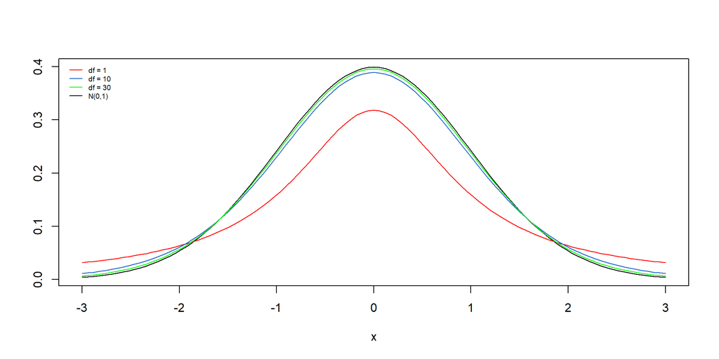

## R: `rt()`

- A random sample from a t-distribution

```r
s <- rt(n = 1000, df = 59)
head(s)
```

```
[1]  0.37720674  1.68018719  1.54092090 -0.07218686 -1.93732391  1.13405265
```

## R: `pt()`

- What is the cumulative proportion smaller than $-1.2$, or $P(T < -1.2)$, for a t-distribution with $\text{df} = 60$?

```r
pt(q = -1.2, df = 60, lower.tail = TRUE)
```

```
[1] 0.1174281
```

## R: `qt()`

- What is the critical value for the lowest and largest $2.5$% of a t-distribution with $\text{df} = 40$?

```r
qt(p = c(0.025, 0.975), df = 40)
```

```
[1] -2.021075  2.021075
```

## Other distributions

- Continuous distributions
  - normal
  - student t-distribution
  - chi squared
- Discrete
  - binomial
  - poisson
- beta, gamma, negative binomial, Weibull, etc.

## Intermezzo: Matt Bognar’s app

Let’s look at the binomial distribution:

https://mabognar.github.io/apps/

## Distributions in statistics

- to describe and understand a variable
- to evaluate the outcome of a statistical test
- to measure uncertainty around an estimate or parameter

## Estimation

- point estimation
- interval estimation<sup>1</sup>
[^1]: an interval is not a distribution.

## Point estimation

| (Population)parameter | (Sample)statistic |
| --- | --- |
| $\mu$ | $\bar{X}$ |
| $\sigma$ | $s$ |

## Interval estimation

$$\frac{\bar{X}-\mu}{\frac{\sigma}{\sqrt{n}}}\sim N(0,1)$$

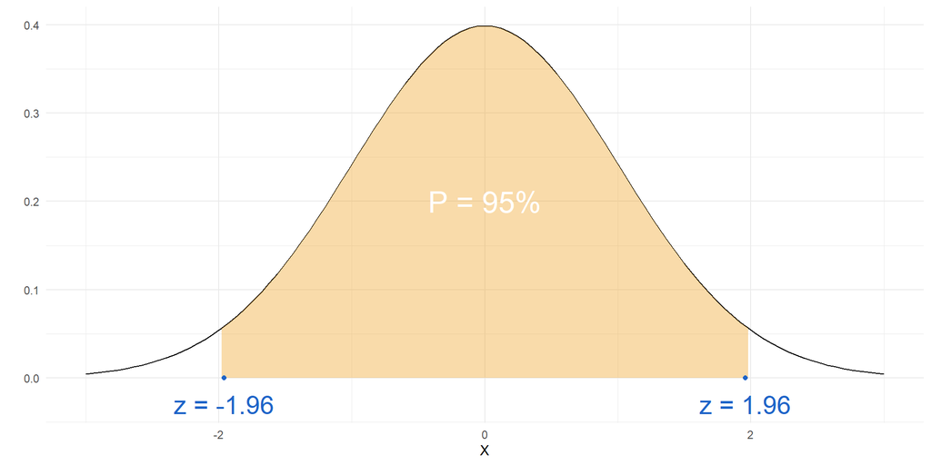

## Interval estimation

- $\text{lower bound}=\bar{X}-z_{\alpha/2}*SE$
- $\text{upper bound}=\bar{X}+z_{\alpha/2}*SE$

## Example

- $N = 40$
- $\sigma = 3$
- $\bar{X}=41$

```r
X_bar <- 41
n <- 40
sigma <- 3
SE <- sigma/sqrt(n)
Z_alpha <- abs(qnorm(p = 0.05/2))
lower <- X_bar - Z_alpha*SE
upper <- X_bar + Z_alpha*SE
c(lower, upper)
```

```
[1] 40.07031 41.92969
```

## Your turn

Change $n$, $\sigma$, $\bar{X}$ and compare the intervals.

```r
X_bar <- 41
n <- 10
sigma <- 3
SE <- sigma/sqrt(n)
Z_alpha <- abs(qnorm(p = 0.05/2))
lower <- X_bar - Z_alpha*SE
upper <- X_bar + Z_alpha*SE
c(lower, upper)
```

```
[1] 39.14061 42.85939
```

## Interval estimation

$$P\left(\bar{X} - z_{\alpha/2} \frac{\sigma}{\sqrt{n}} < \mu < \bar{X} + z_{\alpha/2} \frac{\sigma}{\sqrt{n}}\right) = 100\% - \alpha$$

## Interval estimation ($\sigma$ unknown)

We first estimate $\sigma$ based on a sample:

```r
set.seed(4635) # to get the same sample
dd <- rnorm(n = 40, mean = 41, sd = 3)
head(dd, 20)
```

```
 [1] 37.68313 42.80806 41.31365 46.18608 39.60299 40.31846 40.82984 39.37190
 [9] 38.87229 41.44719 36.89051 41.90103 47.36603 41.36113 40.41350 38.00208
[17] 46.64815 36.89039 46.52108 42.28382
```

## Interval estimation ($\sigma$ unknown)

```r
X_bar <-  mean(dd)
n <- 40
s <- sd(dd)
SE <- s/sqrt(n)
t_alpha <- abs(qt(p = 0.025,df = n-1))
lower <- X_bar - t_alpha*SE
upper <- X_bar + t_alpha*SE
c(lower, upper)
```

```
[1] 40.20862 41.89450
```

## Your turn

- Go to <https://mabognar.github.io/apps/
- Create a t-distribution with 40 degrees of freedom
- find the critical value for a 95% CI.

## Exercise 7

What is the 95% CI for `Duration_ms` from Verbeke & Van Praet (2025)?

## Notes

1. The confidence interval only says something about the **method** we use.
2. A confidence interval is an interval with a lower bound and an upper bound. All values between these bounds are equally likely. The CI is therefore **not** a probability density function. Thus, it is not the case that $\mu$ becomes less likely towards the bounds.

# Null hypothesis significance testing

## The procedure

1. Formulate null hypothesis ($H_0$) and alternative hypothesis ($H_A$)
2. Choose significance level (alpha)(often 5%)
3. Choose test
4. Perform test (+ test assumptions)
5. Interpret findings

## Goal & Test

- difference between two means: two-sample t-test
- difference between a mean with an expected mean: one-sample t-test
- difference between two related means: paired sampled t-test
- difference between two proportions: test for two proportions
- association between two categorical variables: chi-squared test
- linear association between two continuous variables: simple regression model
- difference between three or more means: ANOVA
- linear association between two continuous variables taking into account a categorical variable: ANCOVA
- non-parametric alternatives:
  - t-test: Mann-Whitney-Wilcoxon test
  - ANOVA: Kruskal-Wallis test
- effect of various continuous and categorical predictors on a continuous outcome: regression model
- regression model with a binary outcome: logistic regression
- regression with a count outcome: poisson regression
- taking into account clustering: mixed effects/hierarchical models
- etc.

## Essence of any test

- Goal: compare a difference/measure an effect **taking into account** variability (= what would happen if we did this over and over again).
- Variability is captured by the Standard Error
- The result of any test (in a frequentist paradigm) is a **test statistic**
- Question: how “special” is this **test statistic**?
- Answer: look at the P-value of the test statistic.
- Remember: test statistic = z-score; P-value = cumulative proportion